# Laboratorio Modulo 6

Soluzioni

Author

Ottavia Epifania

# 1 Introduzione

Questo laboratorio utilizza un set di dati associato a variabili legate ad una ricerca di psicologia cognitiva applicata. Nello specifico, in questa ricerca sono state raccolte delle misure di performance legate a due task (compiti) specifici per l’utilizzo di uno sportwatch. Ad un gruppo di *48 persone* (che non avevano mai utilizzato uno sportwatch in precedenza) è stato chiesto di eseguire i due compiti dopo una prima fase di familiarizzazione con l’oggetto durata 15’. Nel primo task (compito di sincronizzazione) veniva richiesto alla persona di sincronizzare il workout “corsa” dello sportwatch attraverso il Bluetooth Smart del proprio smarthphone. Nel secondo task (compito di selezione) veniva richiesto di attivare nell’interfaccia grafica dello sportwatch 3 campi specifici (distanza percorsa, misura battito cardiaco, lap time). Per ciascuno dei due task venivano misurate le seguenti variabili di performance: 1) Successo (codificata come variabile dicotomica 0/1: il valore 1 indica che la persona aveva correttamente eseguito il compito) 2) Time-on-task (tempo di esecuzione del compito, inteso come tempo impiegato dall’individuo per completare corretamente il task o per abbandonare senza successo il task), questa variabile era misurata in secondi. Infine, la prova veniva eseguita in due fasi temporali distinte (t1 e t2). Nello specifico, nella seconda fase (t2) i due task venivano ripetuti per una seconda volta a distanza di 24h dalla prima prova (questo per valutare se vi fosse stato un qualche grado di apprendimento legato all’uso dello smartwatch).

Le variabili nel file di dati `DATASW2.csv` sono le seguenti:

1. `Gender` (sesso della persona): `m` oppure `f`
2. `Age` (età espressa in anni)
3. `SuccT1t1` (variabile successo del primo task nella fase temporale 1)
4. `SuccT1t2` (variabile successo del primo task nella fase temporale 2)
5. `SuccT2t1` (variabile successo del secondo task nella fase temporale 1)
6. `SuccT2t2` (variabile successo del secondo task nella fase temporale 2)
7. `TT1t1` (time-on-task del primo task nella fase temporale 1)
8. `TT1t2` (time-on-task del primo task nella fase temporale 2)
9. `TT2t1` (time-on-task del secondo task nella fase temporale 1)
10. `TT2t2` (time-on-task del secondo task nella fase temporale 2)

# 2 Esercizi

Negli esercizi che seguono precedere le analisi statistico-inferenziali con opportuni metodi grafici.

## 2.1

Si assegni il dataset al data frame `D` (utilizzare la funzione `read.csv()` e non `read.csv2()` in quanto il file di dati è stato creato in un Excel che utilizzava il “.” come separatore decimale). Visualizzare le statistiche descrittive di base delle variabili del data frame.

```r
D <- read.csv("DATASW2.csv")
head(D)
```

```
  Gender Age SuccT1t1 SuccT1t2 SuccT2t1 SuccT2t2 TT1t1 TT1t2 TT2t1 TT2t2
1      m  22        1        1        0        0  9.32  5.77 29.05 27.83
2      m  29        1        1        0        1 21.44 17.06 37.71 34.82
3      m  34        1        0        0        0 19.95 15.06 37.10 32.89
4      f  21        0        1        0        1 17.25 14.51 40.33 35.29
5      f  19        1        1        1        1 10.25  6.14 24.73 23.64
6      m  45        0        1        0        0 17.93 15.97 46.51 41.82
```

```r
D$Gender = as.factor(D$Gender)

summary(D)
```

```
 Gender      Age           SuccT1t1         SuccT1t2         SuccT2t1
 f:19   Min.   :18.00   Min.   :0.0000   Min.   :0.0000   Min.   :0.0000
 m:29   1st Qu.:22.75   1st Qu.:0.0000   1st Qu.:1.0000   1st Qu.:0.0000
        Median :29.50   Median :1.0000   Median :1.0000   Median :0.0000
        Mean   :33.79   Mean   :0.6667   Mean   :0.7917   Mean   :0.1875
        3rd Qu.:44.00   3rd Qu.:1.0000   3rd Qu.:1.0000   3rd Qu.:0.0000
        Max.   :63.00   Max.   :1.0000   Max.   :1.0000   Max.   :1.0000
    SuccT2t2          TT1t1           TT1t2            TT2t1
 Min.   :0.0000   Min.   : 3.92   Min.   : 1.940   Min.   :24.73
 1st Qu.:0.0000   1st Qu.:11.85   1st Qu.: 9.835   1st Qu.:34.58
 Median :0.0000   Median :15.68   Median :12.620   Median :37.99
 Mean   :0.4583   Mean   :15.77   Mean   :12.309   Mean   :39.82
 3rd Qu.:1.0000   3rd Qu.:18.91   3rd Qu.:15.178   3rd Qu.:43.31
 Max.   :1.0000   Max.   :26.99   Max.   :19.490   Max.   :62.50
     TT2t2
 Min.   :23.64
 1st Qu.:31.36
 Median :34.95
 Mean   :36.09
 3rd Qu.:39.18
 Max.   :57.81
```

## 2.2

Verificare se l’età media delle donne sia significativamente differente da quella dei maschi.

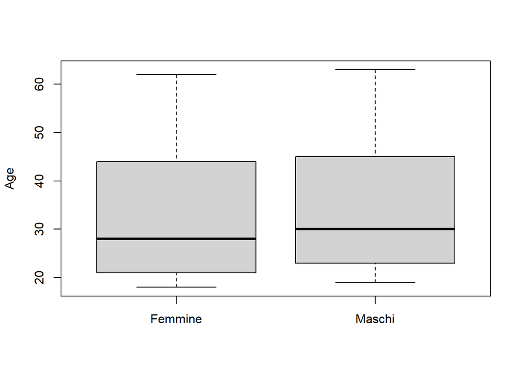

```r
boxplot(D$Age[D$Gender=="f"],
        D$Age[D$Gender=="m"],names=c("Femmine","Maschi"),ylab="Age")
```

```r
# in alternativa
# boxplot(D$Age ~ D$Gender,ylab="Et?")
t.test(D$Age[D$Gender=="f"],D$Age[D$Gender=="m"])
```

```
    Welch Two Sample t-test

data:  D$Age[D$Gender == "f"] and D$Age[D$Gender == "m"]
t = -0.28361, df = 38.426, p-value = 0.7782
alternative hypothesis: true difference in means is not equal to 0
95 percent confidence interval:
 -8.533889  6.435886
sample estimates:
mean of x mean of y
 33.15789  34.20690
```

## 2.3

Verificare se il tempo medio impiegato dal gruppo dei maschi nel primo task al tempo t1 sia significativamente differente da quello impiegato (per lo stesso task e allo stesso tempo) dal gruppo delle donne. Ripetere le analisi per il secondo task.

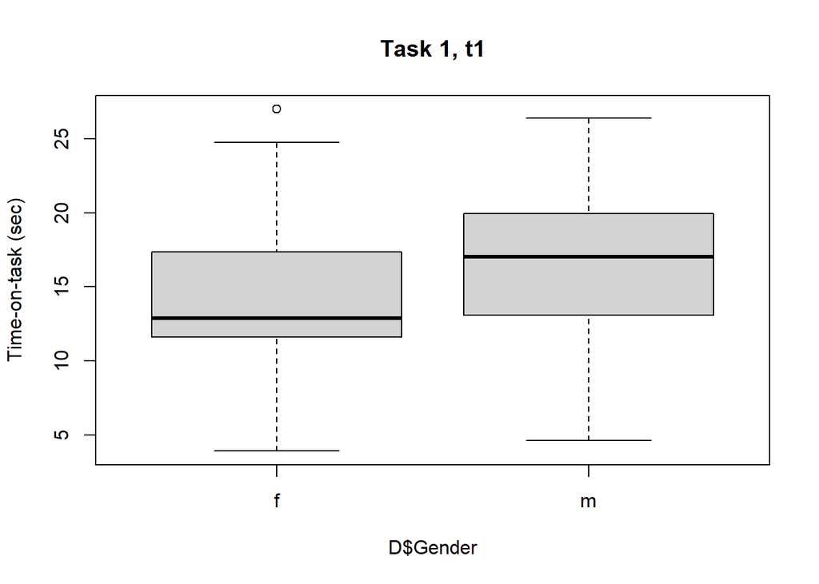

```r
boxplot(D$TT1t1 ~ D$Gender,ylab="Time-on-task (sec)",main="Task 1, t1")
```

```r
t.test(D$TT1t1[D$Gender=="f"],D$TT1t1[D$Gender=="m"])
```

```
    Welch Two Sample t-test

data:  D$TT1t1[D$Gender == "f"] and D$TT1t1[D$Gender == "m"]
t = -1.0584, df = 35.782, p-value = 0.297
alternative hypothesis: true difference in means is not equal to 0
95 percent confidence interval:
 -5.289358  1.662389
sample estimates:
mean of x mean of y
 14.67789  16.49138
```

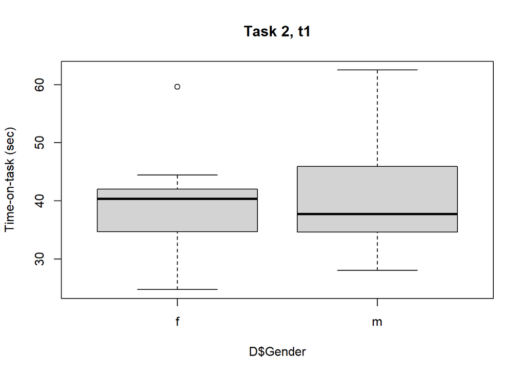

```r
boxplot(D$TT2t1 ~ D$Gender,ylab="Time-on-task (sec)",main="Task 2, t1")
```

```r
t.test(D$TT2t1[D$Gender=="f"],D$TT2t1[D$Gender=="m"])
```

```
    Welch Two Sample t-test

data:  D$TT2t1[D$Gender == "f"] and D$TT2t1[D$Gender == "m"]
t = -0.39016, df = 44.288, p-value = 0.6983
alternative hypothesis: true difference in means is not equal to 0
95 percent confidence interval:
 -5.542914  3.744584
sample estimates:
mean of x mean of y
 39.27842  40.17759
```

## 2.4

Valutare se il tempo complessivo nel primo task sia significativamente superiore nel gruppo delle persone con età superiore ai 40 anni (rispetto a $\leq 40$). Qui per tempo complessivo si intende la somma dei time-on-task nei due tempi t1 e t2.

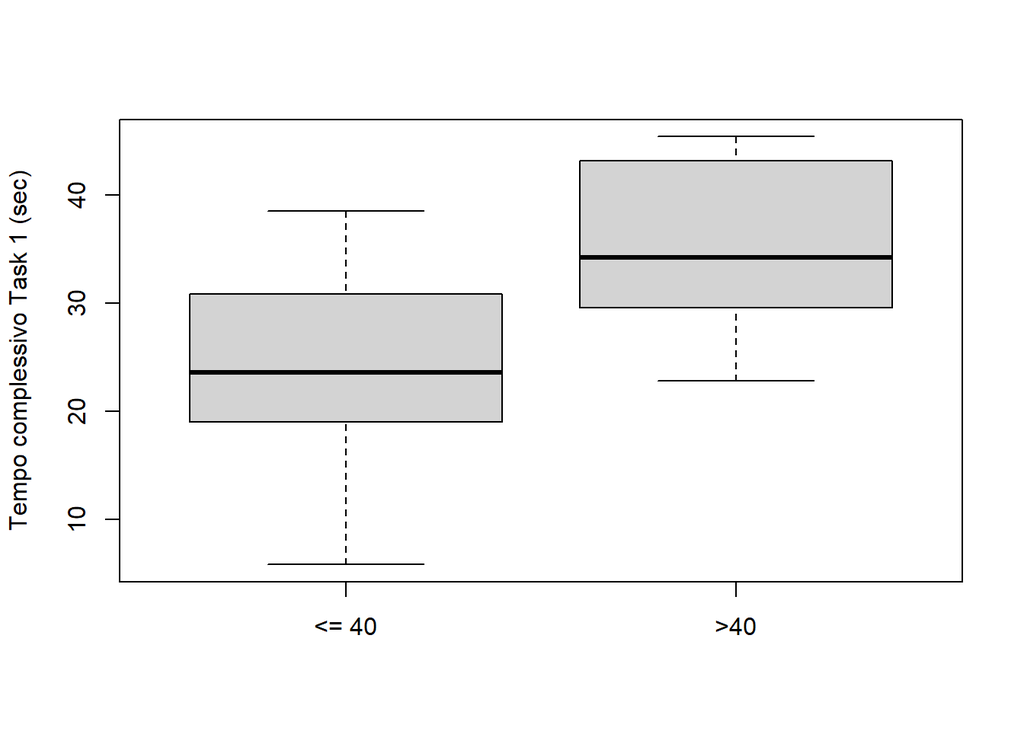

```r
TCT1 <- D$TT1t1 + D$TT1t2

boxplot(TCT1[D$Age <= 40],TCT1[D$Age > 40],names=c("<= 40",">40"),ylab="Tempo complessivo Task 1 (sec)")
```

```r
t.test(TCT1[D$Age <= 40],TCT1[D$Age > 40],alternative="less")
```

```
    Welch Two Sample t-test

data:  TCT1[D$Age <= 40] and TCT1[D$Age > 40]
t = -4.8603, df = 34.971, p-value = 1.224e-05
alternative hypothesis: true difference in means is less than 0
95 percent confidence interval:
      -Inf -7.527007
sample estimates:
mean of x mean of y
 23.99613  35.53412
```

```r
# in alternativa
# t.test(TCT1[D$Age > 40],TCT1[D$Age <= 40],alternative="greater")
```

## 2.5

Il tempo impiegato dalle persone che hanno successo nel secondo task al tempo t1 è significativamente inferiore rispetto a coloro che falliscono (nel secondo task al tempo t1)?

```r
boxplot(D$TT2t1 ~ D$SuccT2t1,ylab="Time-on-task (sec)",main="Task 2, t1")
t.test(D$TT2t1[D$SuccT2t1==1],D$TT2t1[D$SuccT2t1==0],alternative="less")
```

```
    Welch Two Sample t-test

data:  D$TT2t1[D$SuccT2t1 == 1] and D$TT2t1[D$SuccT2t1 == 0]
t = -1.4727, df = 13.255, p-value = 0.08208
alternative hypothesis: true difference in means is less than 0
95 percent confidence interval:
      -Inf 0.8109699
sample estimates:
mean of x mean of y
 36.53889  40.57923
```

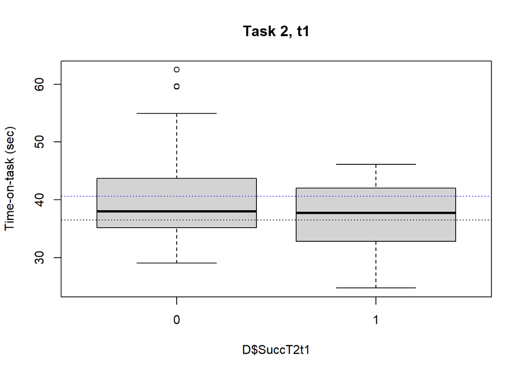

```r
abline(mean(D$TT2t1[D$SuccT2t1==1]),0,lty=3)   # posizione media campionaria per gruppo successo
abline(mean(D$TT2t1[D$SuccT2t1==0]),0,lty=3,col="blue") # posizione media campionaria per gruppo insuccesso
```

```r
# notare come le posizioni di queste medie differiscano dalle posizioni delle mediane dei boxplot
```

## 2.6

Verificare se il tempo medio impiegato nel secondo task al tempo t1 sia significativamente superiore rispetto al valore della mediana campionaria calcolata sui tempi registrati al secondo task sempre al tempo t1.

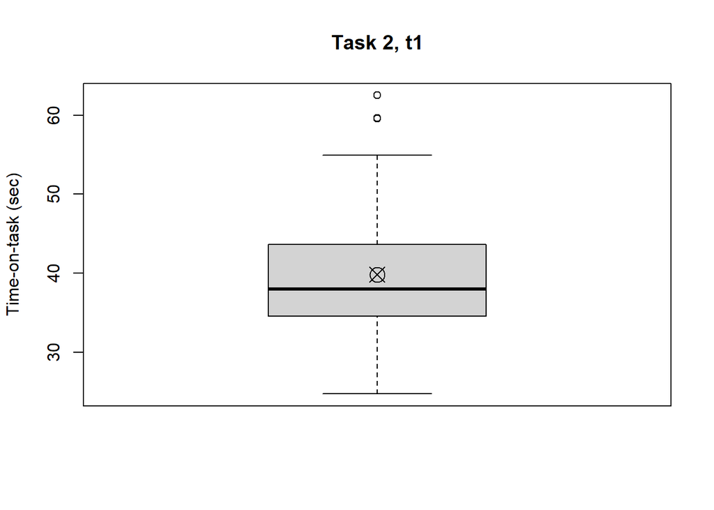

```r
boxplot(D$TT2t1,ylab="Time-on-task (sec)",main="Task 2, t1")
points(mean(D$TT2t1),pch=13, cex = 2)  # posizione della media campionaria
```

```r
t.test(D$TT2t1,mu=median(D$TT2t1),alternative="greater")
```

```
    One Sample t-test

data:  D$TT2t1
t = 1.5569, df = 47, p-value = 0.0631
alternative hypothesis: true mean is greater than 37.995
95 percent confidence interval:
 37.85298      Inf
sample estimates:
mean of x
 39.82167
```

## 2.7

Vi è un miglioramento statisticamente significativo nella performance temporale (time-on-task) del primo compito (task) nel passare dalla fase t1 alla t2? Ripetere l’analisi anche per il secondo compito (task).

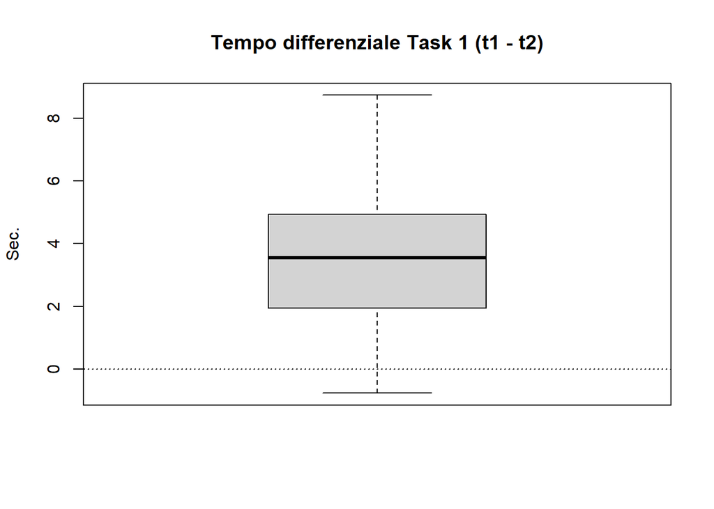

```r
TT1D <- D$TT1t1 - D$TT1t2
boxplot(TT1D,main="Tempo differenziale Task 1 (t1 - t2)",ylab="Sec.")
abline(0,0,lty=3)
```

```r
t.test(D$TT1t1,D$TT1t2,paired=T,alternative="greater")
```

```
    Paired t-test

data:  D$TT1t1 and D$TT1t2
t = 10.407, df = 47, p-value = 4.345e-14
alternative hypothesis: true mean difference is greater than 0
95 percent confidence interval:
 2.906004      Inf
sample estimates:
mean difference
       3.464583
```

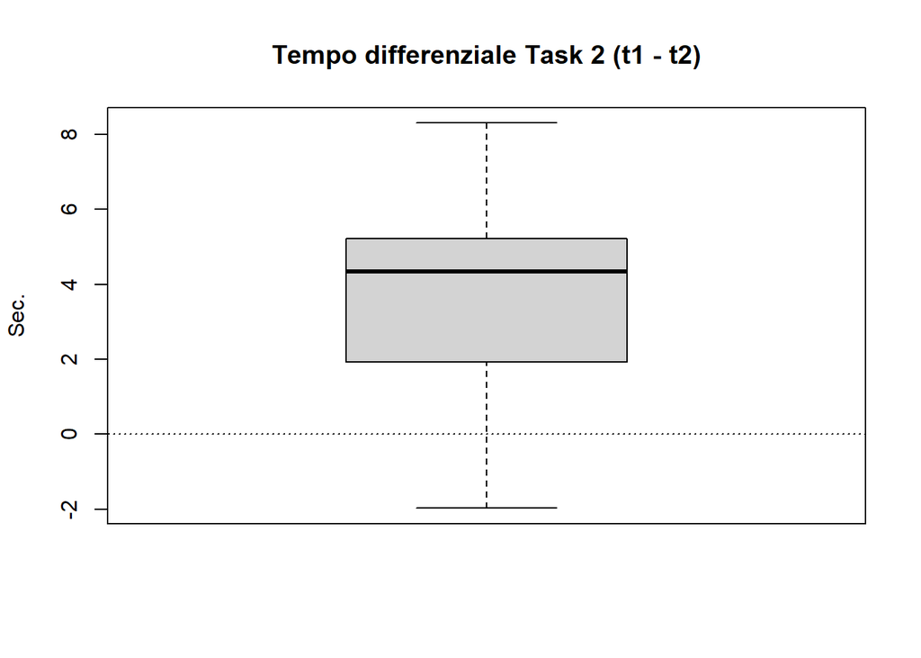

```r
TT2D <- D$TT2t1 - D$TT2t2
boxplot(TT2D,main="Tempo differenziale Task 2 (t1 - t2)",ylab="Sec.")
abline(0,0,lty=3)
```

```r
t.test(D$TT2t1,D$TT2t2,paired=T,alternative="greater")
```

```
    Paired t-test

data:  D$TT2t1 and D$TT2t2
t = 10.386, df = 47, p-value = 4.647e-14
alternative hypothesis: true mean difference is greater than 0
95 percent confidence interval:
 3.132819      Inf
sample estimates:
mean difference
       3.736458
```

## 2.8

Ripetere l’esercizio 7, questa volta limitatamente al solo gruppo delle donne.

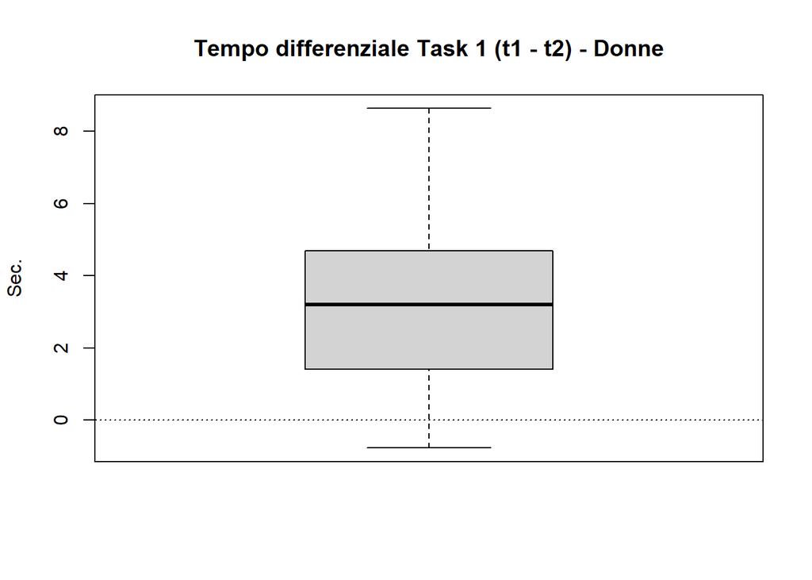

```r
TT1Df <- D$TT1t1[D$Gender=="f"] - D$TT1t2[D$Gender=="f"]
boxplot(TT1Df,main="Tempo differenziale Task 1 (t1 - t2) - Donne",ylab="Sec.")
abline(0,0,lty=3)
```

```r
t.test(D$TT1t1[D$Gender=="f"],D$TT1t2[D$Gender=="f"],paired=T,alternative="greater")
```

```
    Paired t-test

data:  D$TT1t1[D$Gender == "f"] and D$TT1t2[D$Gender == "f"]
t = 5.8176, df = 18, p-value = 8.205e-06
alternative hypothesis: true mean difference is greater than 0
95 percent confidence interval:
 2.319313      Inf
sample estimates:
mean difference
       3.304211
```

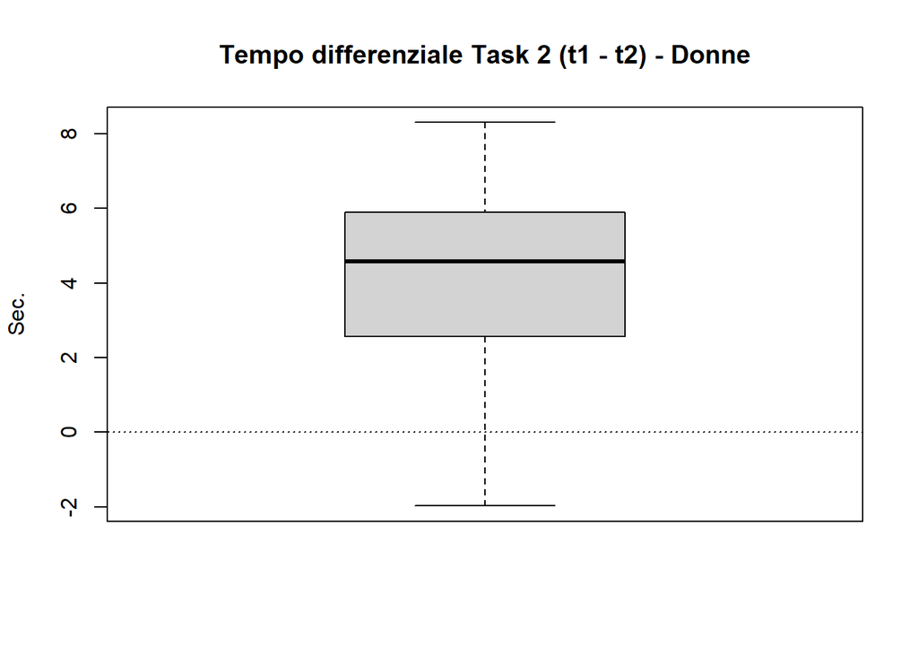

```r
TT2Df <- D$TT2t1[D$Gender=="f"] - D$TT2t2[D$Gender=="f"]
boxplot(TT2Df,main="Tempo differenziale Task 2 (t1 - t2) - Donne",ylab="Sec.")
abline(0,0,lty=3)
```

```r
t.test(D$TT2t1[D$Gender=="f"],D$TT2t2[D$Gender=="f"],paired=T,alternative="greater")
```

```
    Paired t-test

data:  D$TT2t1[D$Gender == "f"] and D$TT2t2[D$Gender == "f"]
t = 6.7309, df = 18, p-value = 1.306e-06
alternative hypothesis: true mean difference is greater than 0
95 percent confidence interval:
 3.13868     Inf
sample estimates:
mean difference
       4.227895
```

## 2.9

Verificare se vi sia una associazione statisticamente significativa tra età (espressa in due classi: $\leq 40$ e $> 40$) e l’ottenimento di un successo nel completamento del primo task alla fase t1. Ripetere l’analisi, questa volta relativamente alla fase t2.

```r
# Eta categoriale
Ecat <- D$Age
Ecat[D$Age <= 40] <- 1
Ecat[D$Age > 40] <- 2
Ecat <- as.factor(Ecat)
TAB <- table(Ecat,D$SuccT1t1)
chisq.test(TAB)
```

```
    Pearson's Chi-squared test with Yates' continuity correction

data:  TAB
X-squared = 6.0228, df = 1, p-value = 0.01412
```

```r
TAB2 <- table(Ecat,D$SuccT1t2)
chisq.test(TAB2)
```

```
    Pearson's Chi-squared test with Yates' continuity correction

data:  TAB2
X-squared = 4.8331, df = 1, p-value = 0.02792
```

## 2.10

Vi è una qualche relazione tra successo al task 2 alla fase t2 rispetto al genere della persona? E rispetto al task 1 alla fase 1?

```r
TAB3 <- table(D$Gender,D$SuccT2t2)
chisq.test(TAB3)
```

```
    Pearson's Chi-squared test with Yates' continuity correction

data:  TAB3
X-squared = 1.1264, df = 1, p-value = 0.2885
```

```r
TAB4 <- table(D$Gender,D$SuccT1t1)
chisq.test(TAB4)
```

```
    Pearson's Chi-squared test with Yates' continuity correction

data:  TAB4
X-squared = 0.53358, df = 1, p-value = 0.4651
```